# Introduction to data science - Ch5

# Welcome to melda.io

Sampling is an important step of the whole data science methodology :

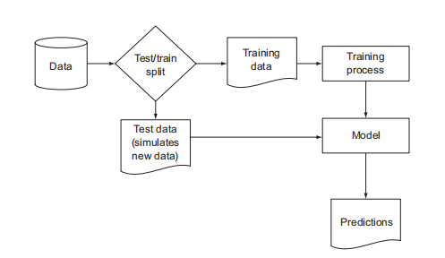

sampling -> representative small portion

## why sampling?

- because it’s faster to run and graph smaller datasets
- to create train and test samples

## Sampling for training and testing

- Split the test into training and test sets
- Develop model on the training set
- Test the validity of the model with the test set (also called the hold-out set)

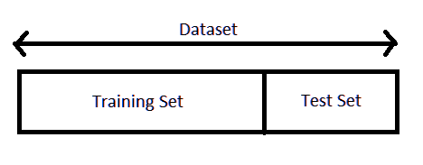

test and train

### Keep in mind :

- The sampled dataset needs to be representative of the initial dataset
- Split early. Don’t wait.
- Some people also use training-calibration-test

## Practice

Let us sample segment the customer data using sampling.

First read the data :

```r
custdata <- read.table('https://github.com/scizmeli/datascience_class_helper_files/raw/master/custdata.tsv', header=T, sep='\t')
dim(custdata)
head(custdata)
```

To perform a sampling with 10% of the data for the test and 90% for the training :

```r
set.seed(100)# her seferinde degismemesi icin set.seed() fonksiyonun kullanılması gerekir

# Create a new column __gp__ in the dataset and populate it with random numbers :
custdata$gp <- runif(dim(custdata)[1])# rassal sayı üretilir
# yeni bir sütun yaratıp gp adını verdik

# Create training and test sets
testSet <- subset(custdata, custdata$gp <= 0.1)     # Note: 2
trainingSet <- subset(custdata, custdata$gp > 0.1)  # Note: 3
# Check the dimensions of the created sets
dim(testSet)[1]
dim(trainingSet)[1]

# Always double-check
nrow(testSet) + nrow(trainingSet) == nrow(custdata)
```

## Group sampling

If every row of your dataset does not have one-to-one correspondance with your parameter to model, then segmentation with sample group would not work. Then group sampling is needed. As an example, consider the following dataset :

```r
household_id <- factor(c("hh1", "hh2",  "hh2",  "hh2",  "hh3",  "hh3",  "hh4",  "hh5",  "hh5",  "hh5"))
cust_id <- factor(c("cust1","cust2","cust3","cust1","cust1","cust3","cust2","cust3","cust4","cust4"))
income <- round(runif(length(household_id))*100000)
hhdata <- data.frame(household_id=household_id, cust_id=cust_id, income=income)
hhdata
```

We can now create the **gp** column based on the group *household_id*

```r
hh <- unique(hhdata$household_id)
households <- data.frame(household_id = hh, gp = runif(length(hh)))
hhdata <- merge(hhdata, households, by="household_id")# brlestirme
head(hhdata)
```

### Keep in mind :

```r
# ornekleme islemi gerceklestirildi
set.seed(333)
df<- mtcars
df$gp <- runif(dim(mtcars)[1])
testSet <- subset(df, df$gp <= 0.2)     # Note: 2
trainingSet <- subset(df, df$gp > 0.2)  # Note: 3

dim(test)
```

```r
#örnekleme islemi gerceklestirildi
set.seed(333)

sample = round(nrow(mtcars)*.80)
index <- sample(seq_len(nrow(mtcars)), size = sample)

train <- mtcars[index, ]
test <- mtcars[-index, ]

dim(test)
```